# INFO 370 Freeform Assignment 1

Author

Simran Gupta

Published

April 22, 2025

## Load Libraries

Set up the libraries required for visualizations.

## Load Data

```
Rows: 383
Columns: 13
$ Age             <int> 27, 34, 30, 62, 62, 52, 41, 46, 51, 40, 75, 59, 49, 50…
$ Gender          <chr> "F", "F", "F", "F", "F", "M", "F", "F", "F", "F", "F",…
$ Hx.Radiothreapy <chr> "No", "No", "No", "No", "No", "No", "No", "No", "No", …
$ Adenopathy      <chr> "No", "No", "No", "No", "No", "No", "No", "No", "No", …
$ Pathology       <chr> "Micropapillary", "Micropapillary", "Micropapillary", …
$ Focality        <chr> "Uni-Focal", "Uni-Focal", "Uni-Focal", "Uni-Focal", "M…
$ Risk            <chr> "Low", "Low", "Low", "Low", "Low", "Low", "Low", "Low"…
$ T               <chr> "T1a", "T1a", "T1a", "T1a", "T1a", "T1a", "T1a", "T1a"…
$ N               <chr> "N0", "N0", "N0", "N0", "N0", "N0", "N0", "N0", "N0", …
$ M               <chr> "M0", "M0", "M0", "M0", "M0", "M0", "M0", "M0", "M0", …
$ Stage           <chr> "I", "I", "I", "I", "I", "I", "I", "I", "I", "I", "I",…
$ Response        <chr> "Indeterminate", "Excellent", "Excellent", "Excellent"…
$ Recurred        <chr> "No", "No", "No", "No", "No", "No", "No", "No", "No", …
```

## Data Wrangling

Selected certain columns

```
Rows: 383
Columns: 6
$ Age             <int> 27, 34, 30, 62, 62, 52, 41, 46, 51, 40, 75, 59, 49, 50…
$ Gender          <chr> "F", "F", "F", "F", "F", "M", "F", "F", "F", "F", "F",…
$ Hx.Radiothreapy <chr> "No", "No", "No", "No", "No", "No", "No", "No", "No", …
$ Stage           <chr> "I", "I", "I", "I", "I", "I", "I", "I", "I", "I", "I",…
$ Response        <chr> "Indeterminate", "Excellent", "Excellent", "Excellent"…
$ Recurred        <chr> "No", "No", "No", "No", "No", "No", "No", "No", "No", …
```

Filter based on gender

```
Rows: 42
Columns: 6
$ Age             <int> 31, 20, 20, 40, 38, 36, 33, 75, 62, 56, 42, 67, 38, 27…
$ Gender          <chr> "M", "M", "M", "M", "M", "M", "M", "M", "M", "M", "M",…
$ Hx.Radiothreapy <chr> "No", "No", "No", "No", "No", "No", "No", "Yes", "No",…
$ Stage           <chr> "I", "I", "I", "I", "I", "I", "I", "IVB", "I", "I", "I…
$ Response        <chr> "Structural Incomplete", "Structural Incomplete", "Str…
$ Recurred        <chr> "Yes", "Yes", "Yes", "Yes", "Yes", "Yes", "Yes", "Yes"…
```

```
Rows: 66
Columns: 6
$ Age             <int> 26, 36, 35, 18, 62, 56, 62, 17, 21, 21, 31, 34, 60, 60…
$ Gender          <chr> "F", "F", "F", "F", "F", "F", "F", "F", "F", "F", "F",…
$ Hx.Radiothreapy <chr> "No", "No", "No", "No", "No", "No", "No", "No", "No", …
$ Stage           <chr> "I", "I", "I", "I", "I", "I", "I", "I", "I", "I", "I",…
$ Response        <chr> "Structural Incomplete", "Indeterminate", "Structural …
$ Recurred        <chr> "Yes", "Yes", "Yes", "Yes", "Yes", "Yes", "Yes", "Yes"…
```

## Data Visualization

How does age affect recurrence risk?

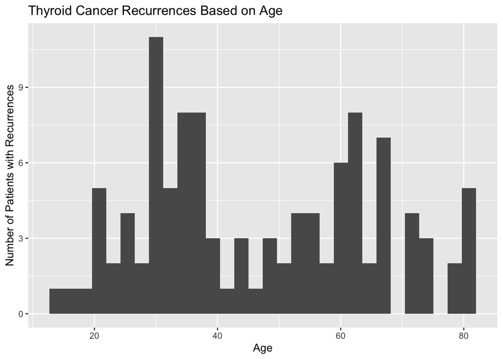

This visualization shows that the number of patients who experienced a recurrence of thyroid cancer varied by age. Individuals in their 30’s had more recorded recurrences compared to teenagers. However, it is worth noting that the sample size of those in various age groups may not have been evenly distributed which would skew this data.

What is the relationship between treatment response and recurrence?

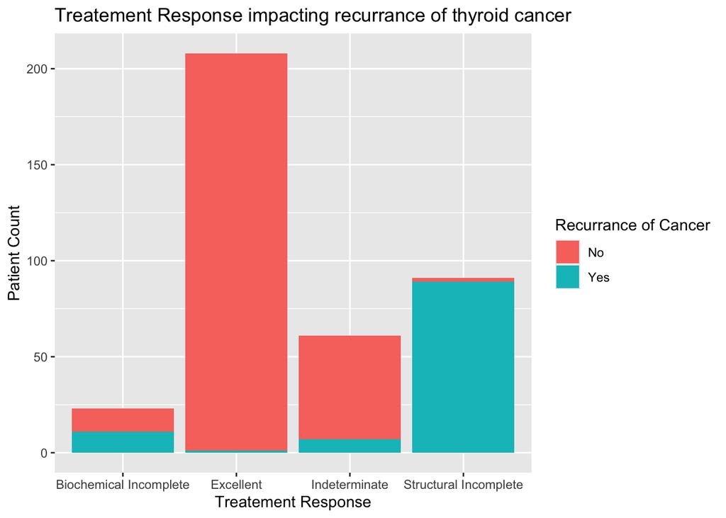

We would assume that an excellent treatment would eliminate thyroid cancer from reoccurring however this visualization shows that even with excellent treatment, there is a chance of recurrence of thyroid cancer. This highlights how thyroid cancer can be very unpredictable, emphasizing the importance of continued monitoring and follow up care even after an excellent treatment response.

## Conclusion

Overall, the data suggest that thyroid cancer recurrence differs between age groups. However, there may have been an uneven distribution of patients across age groups that would skew observed patterns. Additionally, even if a treatment response is excellent, it doesn’t mean that thyroid cancer has completely been eradicated. It is still important to keep monitoring cancer as it can come back anytime. However, it’s important to acknowledge that these findings may be influenced by limitations in the dataset, including possible sampling biases, which can affect the reliability of conclusions drawn.